# hm4

### CCA Banco vs Campaña pasada

```r
# set of variables
bank_set <- c('default','balance','housing','loan')
past_campgn_set <- c('contact','days','duration','poutcome')

#select variables
df2 <- df_main[,cbind(bank_set, past_campgn_set)]

#dummies for bank info
df2[,'default'] <- ifelse( df2[,'default'] == 'yes', 1, 0)
df2[,'housing'] <- ifelse( df2[,'housing'] == 'yes', 1, 0)
df2[,'loan'] <- ifelse( df2[,'loan'] == 'yes', 1, 0)

#cols to numeric
df2[,'contact'] <- as.numeric(as.character(df2[,'contact']))
```

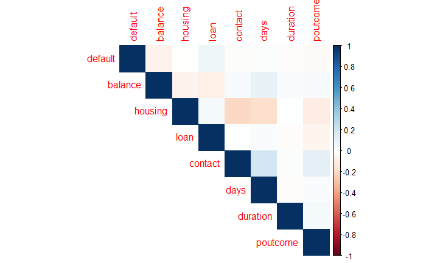

```r
R2 <- cor(df2)
corrplot(R2, method = 'color', type = 'upper')
```

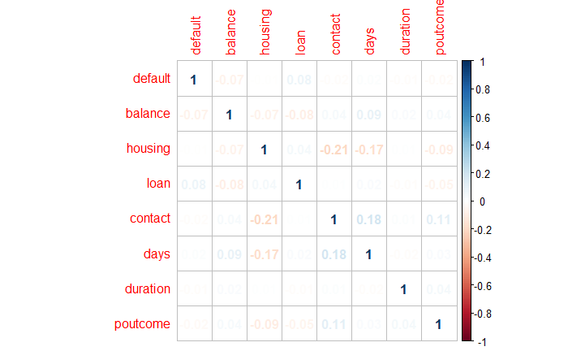

```r
corrplot(R2, method = 'number')
```

Vemos también que en este caso las vvariables tienen poca relaición entre ellas

```r
# set sets
bank_lis <- c("default",  "balance",  "housing",  "loan")
bank_matrix <- df2[,bank_lis]

pc_lis <- c('contact','days','duration','poutcome')
pc_matrix <- df2[,pc_lis]

#CCA analisis
cca2 <- stats::cancor(x = bank_matrix, y = pc_matrix, xcenter = FALSE, ycenter = FALSE)

cca2
```

```
$cor
[1] 0.72738933 0.07882621 0.05857482 0.02517668

$xcoef
                [,1]          [,2]          [,3]          [,4]
default 2.730744e-03  1.661810e-03 -5.916925e-03 -3.473774e-02
balance 4.954740e-07  1.178662e-06  7.053696e-07 -7.406059e-08
housing 4.577685e-03 -4.923153e-03  1.496003e-03  3.329277e-04
loan    2.917294e-03  5.065416e-03 -1.045249e-02  3.508321e-03

$ycoef
                  [,1]          [,2]          [,3]          [,4]
contact   7.800913e-04  3.598070e-03 -3.894837e-03  8.200073e-03
days      1.822257e-05  6.188197e-06  1.404020e-06 -4.208299e-05
duration  3.100408e-06 -1.422381e-05  7.005078e-06  5.800049e-06
poutcome -1.565345e-03  1.285668e-02  2.288570e-02  1.834551e-03

$xcenter
[1] 0 0 0 0

$ycenter
[1] 0 0 0 0
```

Viendo los *loadings*.

Las primeras relaciones canónicas nos muestran lo siguiente:

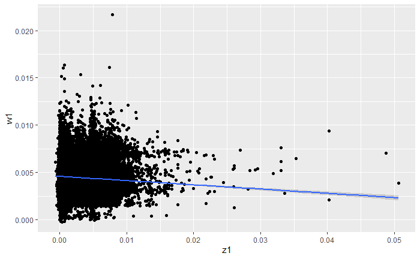

```r
z1 <- as.matrix(bank_matrix) %*% cca2$xcoef[,1]
w1 <- as.matrix(pc_matrix) %*% cca2$ycoef[,1]
data1 <- data.frame(z1, w1)

#plot

#scores
ggplot(data = data1, mapping = aes(x = z1, y = w1)) + geom_point() + geom_smooth(method = 'lm')
```

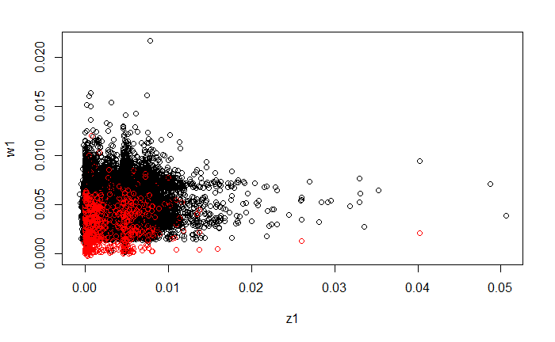

```r
#relationship with previous campaign
plot(x = z1, y = w1, col = df2[,'poutcome'] + 1)
```

Las primeras relaciones canónicas nos muestran lo siguiente:

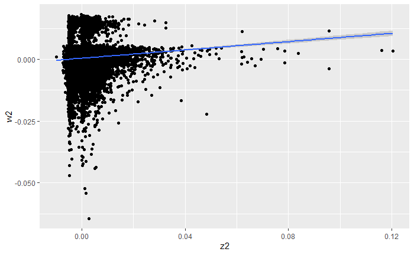

```r
z2 <- as.matrix(bank_matrix) %*% cca2$xcoef[,2]
w2 <- as.matrix(pc_matrix) %*% cca2$ycoef[,2]
data1 <- data.frame(z2, w2)

#plot

#scores
ggplot(data = data1, mapping = aes(x = z2, y = w2)) + geom_point() + geom_smooth(method = 'lm')
```

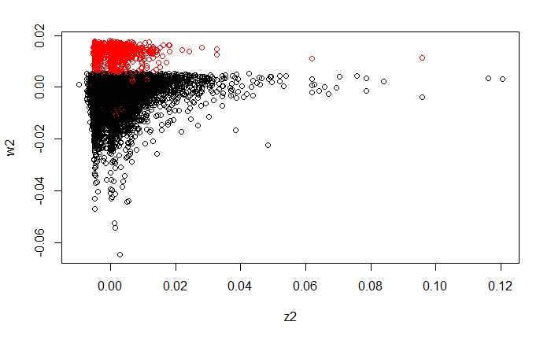

```r
#relationship with previous campaign
plot(x = z2, y = w2, col = df2[,'poutcome'] + 1)
```

## Ejercicio 6

Objetivo: determinar si las variables fisiológicas se relacionan de alguna forma con las variables de ejercicio. a.Analizar la matriz de correlaciones relevantes entre las variables de los dos grupos. b.Probar la hipótesis H0 : Σxy = 0

```r
data.6<-read.table("FitnessClubData.dat", header = T)
```

Analizar la matriz de correlaciones relevantes entre las variables de los dos grupos

```r
(R.6<-cor(data.6))
```

```
                  Peso    Cintura       Pulso Lagartijas Sentadillas      Saltos
Peso         1.0000000  0.8702435 -0.36576203 -0.3896937  -0.4930836 -0.22629556
Cintura      0.8702435  1.0000000 -0.35289213 -0.5522321  -0.6455980 -0.19149937
Pulso       -0.3657620 -0.3528921  1.00000000  0.1506480   0.2250381  0.03493306
Lagartijas  -0.3896937 -0.5522321  0.15064802  1.0000000   0.6957274  0.49576018
Sentadillas -0.4930836 -0.6455980  0.22503808  0.6957274   1.0000000  0.66920608
Saltos      -0.2262956 -0.1914994  0.03493306  0.4957602   0.6692061  1.00000000
```

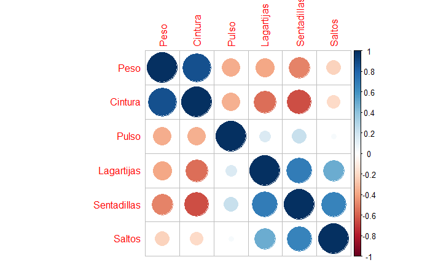

```r
corrplot(R.6)
```

Parece que hay una correlación alta entre sentadillas y la medición de la cintura. También parecen correlacionadas las sentadillas con el peso y las lagartijas con la medida de la cintura.

```r
cor(data.6[,1:3], data.6[,4:6])
```

```
        Lagartijas Sentadillas      Saltos
Peso    -0.3896937  -0.4930836 -0.22629556
Cintura -0.5522321  -0.6455980 -0.19149937
Pulso    0.1506480   0.2250381  0.03493306
```

Las correlaciones entre las variables fisiológicas y de ejercicio son moderadas, la más grande es de -0.65 entre cintura y sentadillas. Hay correlaciones más grandes dentro del conjunto: 0.8702 entre peso y cintura, 0.6957 entre mentones y abdominales, y 0.6692 entre abdominales y saltos.

Probar $H0: cov(x,y)=0$

```r
(cca <- stats::cancor(x = data.6[,1:3], y = data.6[,4:6]))
```

```
$cor
[1] 0.79560815 0.20055604 0.07257029

$xcoef
                [,1]         [,2]         [,3]
Peso    -0.007204730 -0.017508896  0.001774541
Cintura  0.113157401  0.084590855 -0.036255405
Pulso   -0.001881052 -0.007353232 -0.033433269

$ycoef
                    [,1]          [,2]         [,3]
Lagartijas  -0.015167589 -0.0162979716  0.056270024
Sentadillas -0.003864790  0.0004528082 -0.004535007
Saltos       0.003205298  0.0047521419  0.001873747

$xcenter
   Peso Cintura   Pulso
  178.6    35.4    56.1

$ycenter
 Lagartijas Sentadillas      Saltos
       9.45      145.55       70.30
```

```r
(cc <- cancor(x = data.6[,1:3], y = data.6[,4:6]))
```

```
Canonical correlation analysis of:
     3   X  variables:  Peso, Cintura, Pulso
  with   3   Y  variables:  Lagartijas, Sentadillas, Saltos
```

| CanR | CanRSQ | Eigen | percent | cum | scree |
| --- | --- | --- | --- | --- | --- |
| 0.79560815 | 0.632992335 | 1.724738735 | 97.3361014 | 97.33610 | ****************************** |
| 0.20055604 | 0.040222726 | 0.041908396 | 2.3651117 | 99.70121 | * |
| 0.07257029 | 0.005266446 | 0.005294329 | 0.2987869 | 100.00000 |  |

```
Test of H0: The canonical correlations in the
current row and all that follow are zero

     CanR LR test stat approx F numDF  denDF Pr(> F)
1 0.79561      0.35039  2.04823     9 34.223 0.06353 .
2 0.20056      0.95472  0.17578     4 30.000 0.94912
3 0.07257      0.99473  0.08471     1 16.000 0.77475
---
Signif. codes:  0 ‘***’ 0.001 ‘**’ 0.01 ‘*’ 0.05 ‘.’ 0.1 ‘ ’ 1
```

Ahora, para probar la hipótesis necesitamos hacer una prueba. Tenemos con Wilks lambda con p-value de 0.06353>0.05, entonces no rechazamos la hipótesis nula. Por lo que no rechazamos la hipótesis nula de que no hay relación entre los dos conjuntos de variables y concluimos que los dos conjuntos de variables son independientes.

## Ejercicio 7

Datos financieros anuales de firms que estan en bancarrota, dos años de declararse en bancarrota. Las variables son $X_1 =(\text{cashflow})/ (\text{total debt})$, $X_2 =(\text{net income})/ (\text{total assets})$, $X_3 =(\text{current assets})/ (\text{current liabilitites})$ y $X_4 =(\text{current assets})/ (\text{net sales})$

|  | X1 | X2 | X3 | X4 | Population | Grupo |
| --- | --- | --- | --- | --- | --- | --- |
| 1 | -0.45 | -0.41 | 1.09 | 0.45 | 0 | Grupo 1 |
| 2 | -0.56 | -0.31 | 1.51 | 0.16 | 0 | Grupo 1 |
| 3 | 0.06 | 0.02 | 1.01 | 0.40 | 0 | Grupo 1 |
| 4 | -0.07 | -0.09 | 1.45 | 0.26 | 0 | Grupo 1 |
| 5 | -0.10 | -0.09 | 1.56 | 0.67 | 0 | Grupo 1 |
| 6 | -0.14 | -0.07 | 0.71 | 0.28 | 0 | Grupo 1 |

### a) Usando diferentes simbolos para cada grupo, plotea los pares de datos $(x_1,x_2)$ $(x_1,x_3)$ y $(x_1,x_4)$ ¿Parece que los datos son aproximados a una normal bivariada para cualquiera de estos pares?

```r
plt.7.1 <- ggplot(df_7,aes(x = df_7$X1, y = df_7$X2, group = df_7$Grupo)) + geom_point(alpha = 0.75, size = 3.5, aes(shape = Grupo, color = Grupo)) + ylab("X2")+xlab("X1")+ ggtitle("Graph 7.1") + theme_classic()
plt.7.2 <- ggplot(df_7,aes(x = df_7$X1, y = df_7$X3, group = df_7$Grupo)) + geom_point(alpha = 0.75, size = 3.5, aes(shape = Grupo, color = Grupo)) + ylab("X3")+xlab("X1")+ ggtitle("Graph 7.2") + theme_classic()
plt.7.3 <- ggplot(df_7,aes(x = df_7$X1, y = df_7$X4, group = df_7$Grupo)) + geom_point(alpha = 0.75, size = 3.5, aes(shape = Grupo, color = Grupo)) + ylab("X4")+xlab("X1")+ ggtitle("Graph 7.3") + theme_classic()
```

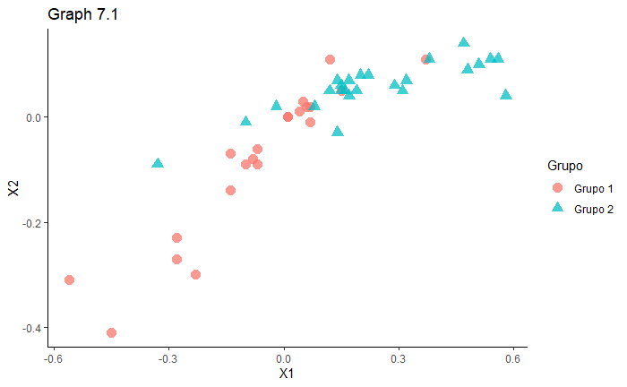

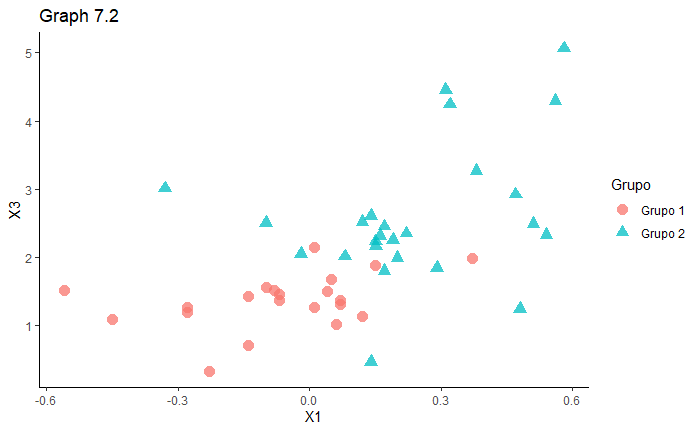

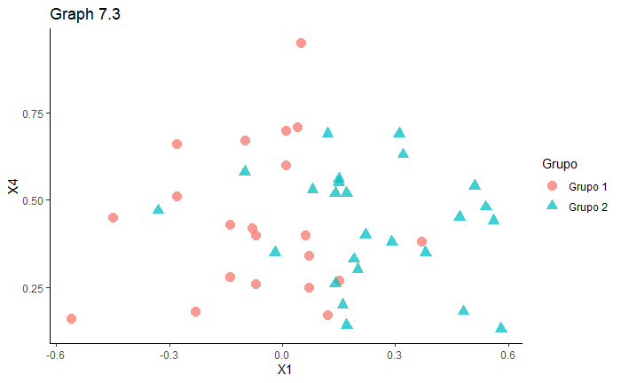

Viendo las graficas, podemos pensar que los datos vienen de una normal bivariada, pues podriamos englobarlas en un elipse, en otras con menor.

### b) Usando las $n_1 = 21$ pares de observaciones $(x_1,x_2)$ de firmas quebradas y las $n_2 = 25$ pares de observaciones $(x_1,x_2)$ no en quiebra, cacule la media muestral para $x_1$ y $x_2$ y la matriz de covarianzas S1 y S2.

Obtenemos las siguientes medias.

```
[1] "Para X1"
    Grupo 1     Grupo 1
-0.06904762 -0.08142857
[1] "Para X2"
Grupo 2 Grupo 2
 0.2352  0.0556
```

```
[1] "S1"
           X1         X2
X1 0.04412905 0.02847643
X2 0.02847643 0.02100286
[1] "S2"
            X1          X2
X1 0.047051000 0.008507167
X2 0.008507167 0.002375667
```

### c) Usando los resultadoes en (b) y asumiendo que ambas muestras aleatorias provienen de una normal bivariada, construya la recgla de clasificación(11-29) con $p_1 = p_2$ y con $c(1|2) = c(2|1)$

Bajo estas hipotesis la regla de decision quedaria dada de la siguiente forma

$$-\frac{1}{2}x_0^T(S_1^{-1} - S_2^{-1})x_0 + (\bar{x}_1S_1^{-1} - \bar{x}_2S_2^{-1})x_0 - k \geq 0$$

de donde obtenemos
$$-\frac{1}{2}x_0^T\left(\begin{array}{cc}
120.88 & -29.74\\
-29.74 & -813.36
\end{array}\right)x_0 + (5.31 , -29.64)x_0 - .16 \geq 0$$

En caso de que el resultado sea positivo, el dato observado pertenece a $\pi_1$ de lo contrario a $\pi_2$

### d) Evalue el desempeño de la regla de clasificación desarrollada en (c) al calcular el error aparente (APER) y el error estimado actual (AER)

El error aparente esta dado por
$$APER = \frac{n_{1M} + n_{2M}}{n_1 + n_2}$$

```
[1] "APER"
[1] 0.196
```

Para el calculo de $E(AER)$.

```
[1] "AER"
[1] 0.217
```

### e) Repita parte c y d asuientod $p_1= 0.05$ y $p_2= 0.95$ y con $c(1|2) = c(2|1)$. ¿Es razonable esta eleccion de prioridades? Explique

$$-\frac{1}{2}x_0^T(S_1^{-1} - S_2^{-1})x_0 + (\bar{x}_1S_1^{-1} - \bar{x}_2S_2^{-1})x_0 - k \geq ln(\frac{p_2}{p_1})$$
donde $ln(\frac{p_2}{p_1}) = ln(19)$ Nuestro clasificador es el siguiente.

$$-\frac{1}{2}x_0^T\left(\begin{array}{cc}
120.88 & -29.74\\
-29.74 & -813.36
\end{array}\right)x_0 + (5.31 , -29.64)x_0 - .16 \geq ln(19)$$

Obtenemos su APER y su AER

```
[1] "APER"
[1] 0.261
```

```
[1] "AER"
[1] 0.261
```

### f) Usando los resultados en (b), forme la pooled covariance matriz $S_pooled$ y construya el discriminante lineal de Fisher. Use essta funcion para clasificar la muestra de observaciones y evalue el APER. ¿El discriminante lineal de fisher un clasificador sensato en este caso? Explique

Obtenemos la matriz.

```
[1] "Spool Matrix"
      X1    X2
X1 0.046 0.017
X2 0.017 0.011
```

El discriminante queda dado por
$$(\bar{x}_1- \bar{x}_2)^TS_{pooled}^{-1}x_0 -\frac{1}{2}(\bar{x}_1- \bar{x}_2)^TS_{pooled}^{-1}(\bar{x}_1+ \bar{x}_2)\geq ln(\frac{p_2}{p_1})$$

```
[1] -4.6390579 -5.2927001 -0.3170438
```

Obtenemos entonces el siguiente disciminante
$$(-4.63,-5.29)x_0 + 0.31 \geq 0$$
Calculamos su APER y AER

```
[1] "APER"
[1] 0.196
```

El APER nos dio igual que cuando asumiamos diferentes Varianzas. Por lo que podemos ver que crear una sola matriz de covarianza ponderada es una buena opción.

### g)Repita de la b)-e) usando los pares de variabeles $(X_1,X_3)$ y $(X_1,X_4)$ ¿Algunas variables parecen ser clasificadas mejor que otras? Explique

Para $(X_1,X_3)$ obtenemos su APER y su AER, , con $p_1 = p_2$

```
[1] "APER"
[1] 0.109
[1] "AER"
[1] 0.13
```

Para $(X_1,X_3)$ obtenemos su APER y su AER, , con $p_1 =.05$ y $p_2 = .95$

```
[1] "APER"
[1] 0.37
[1] "AER"
[1] 0.391
```

Para $(X_1,X_4)$ obtenemos su APER y su AER, con $p_1 = p_2$

```
[1] "APER"
[1] 0.174
[1] "AER"
[1] 0.217
```

Para $(X_1,X_4$ obtenemos su APER y su AER, , con $p_1 =.05$ y $p_2 = .95$

```
[1] "APER"
[1] 0.348
[1] "AER"
[1] 0.457
```

### h) Repita de la b)-e) usando observaciones en las cuatro variables $(X_1,X_2,X_3,X_4)$

Con $p_1 = p_2$ obtenemos el APER y el AER.

```
[1] "APER"
[1] 0.065
[1] "AER"
[1] 0.109
```

Ahora con $p_1 =.05$ y $p_2 = .95$

```
[1] "APER"
[1] 0.196
[1] "AER"
[1] 0.239
```

Parece presentar mejores resultados, y tiene sentido pues damos mas información al modelo.

## Ejercicio 8: GPA & GMAT

### A) Calcular las medias muestrales y la varianza agrupada

```r
#pooled variance

#functions
ni_s <- function(x, population){

  pis <- unique(x[,population])
  ni <- c()
  for(pi in pis)
    ni <- c(ni,length(which(x[,population] == pi)))
  return(ni)
}

#variance
Si_s <- function(x, population){
  Si <- list()
  pis <- unique(x[,population])


  for(pi in pis) {
    Si[[pi]] <- cov(x[x[,population] == pi,-population])

  }
  return(Si)

}

Spool <-  function(df, population = 3){
  #number of populations
  m <- length(unique(df[,population]))

  #size ni
  ni_vec <- ni_s(df, population)

  #individual variance
  Si_list <- Si_s(df, population)

  #pool variance
  #upper part of the fraction
  Spool <- matrix(0,nrow = 2,ncol = 2)

  for(i in 1:m)
    Spool <- Spool +  (ni_vec[i] - 1)[1]  *Si_list[[i]]

  #lower part (constant)
  Spool <- Spool / sum(ni_vec -1)

  return(Spool)
}


#read data
df_r <- read.table('T11-6.DAT')
n <- dim(df_r)[1]


#means and pooled variance
# mean
means <- list()
for(i in 1:3) means[[i]] <- colMeans(df_r[ df_r[,3] == i ,c(1,2)])
means
```

```
[[1]]
        V1         V2
  3.403871 561.225806

[[2]]
      V1       V2
  2.4825 447.0714

[[3]]
        V1         V2
  2.992692 446.230769
```

```r
#pooled variance
Sp <- Spool(df_r)

#print means
# knitr::kable(means, col.names = 'population_mean')

cat("\n La varianza agrupada es: ")
```

```
 La varianza agrupada es:
```

```r
Sp
```

```
            V1          V2
V1  0.03606795   -2.018759
V2 -2.01875915 3655.901121
```

### $W$ y $B$, discriminante generalizado.

```r
sample_bet_g <- function(means, mean_o){
  B <- matrix(0, nrow = 2, ncol = 2)
  for(xbar in means){
    B <- B + (xbar - mean_o) %*% t(xbar - mean_o)
  }
  return(B)
}



#overal mean
g <- length(unique(df_r[,3]))         #num of groups
mean_o <- c(0,0)
for(xbar in means)
  mean_o <- mean_o + xbar             #overal mean of groups

# B
B <- sample_bet_g(means, mean_o)

# W
W <- (n - g)* Sp
Winv <- solve(W)
# eigen W-1B
sWB <-eigen(Winv%*% B)

B
```

```
             V1         V2
[1,]   105.5431   17270.47
[2,] 17270.4726 2829620.88
```

```r
Winv
```

```
             V1           V2
V1 0.3488984937 1.926589e-04
V2 0.0001926589 3.442121e-06
```

```r
sWB
```

```
eigen() decomposition
$values
[1] 53.210090381  0.008262951

$vectors
            [,1]         [,2]
[1,] 0.999998025 -0.999981339
[2,] 0.001987419  0.006109176
```

Clasificaremos el siguiente alumno $x_{0}^{T} = [3.21 \quad 497]$.

```r
#new obs
x.9 <- c(3.21, 497)

# discriminants

#first we make unite variance
v1 <- t(as.matrix(sWB$vectors[,1])) %*% Sp %*% as.matrix(sWB$vectors[,1])
v2 <- t(as.matrix(sWB$vectors[,2])) %*% Sp %*% as.matrix(sWB$vectors[,2])

a1 <- as.matrix(sWB$vectors[,1]) / v1[1]
a2 <- as.matrix(sWB$vectors[,2]) / v2[1]

# discriminants
y <- t(cbind(a1,a2)) %*% x.9
mu_y_p1 <- t(cbind(a1,a2)) %*% means[[1]]
mu_y_p2 <- t(cbind(a1,a2)) %*% means[[2]]
mu_y_p3 <- t(cbind(a1,a2)) %*% means[[3]]


#clasiffy
score_p1 <- t(y - mu_y_p1) %*% (y - mu_y_p1)
score_p2 <- t(y - mu_y_p2) %*% (y - mu_y_p2)
score_p3 <- t(y - mu_y_p3) %*% (y - mu_y_p3)

score_p1
```

```
         [,1]
[1,] 58.28696
```

```r
score_p2
```

```
         [,1]
[1,] 383.2758
```

```r
score_p3
```

```
         [,1]
[1,] 56.32307
```

Vemos que el score más pequeño es el de la población $\prod_{3}$ , por lo que *clasificamos* al estudiante nuevo $x_0$ como alguien en el *border line* .

La clasificación *sí* coincide con la del libro.

## Ejercicio 9

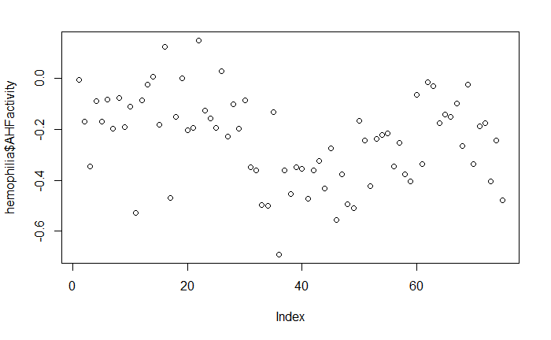

```r
data("hemophilia")
plot(hemophilia$AHFactivity)
```

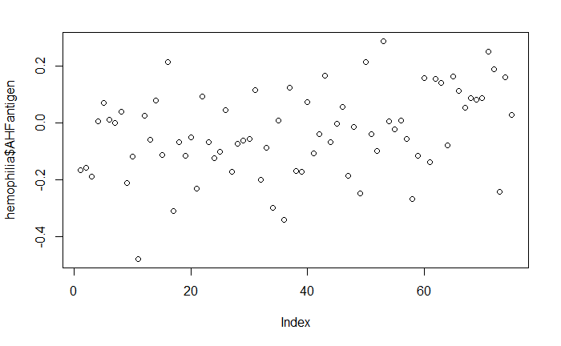

```r
plot(hemophilia$AHFantigen)
```

1. Investiga si son datos normales bivariados

```r
ad.test(hemophilia$AHFactivity)
```

```
    Anderson-Darling normality test

data:  hemophilia$AHFactivity
A = 0.4947, p-value = 0.2089
```

```r
ad.test(hemophilia$AHFantigen)
```

```
    Anderson-Darling normality test

data:  hemophilia$AHFantigen
A = 0.12537, p-value = 0.9852
```

Con una significancia alta, tenemos que se prueba la hipótesis de normalidad bivariada.

2. Obtener la función lineal muestral distriminante

Recordar que el análisis discriminante lineal hace exactamente lo mismo que correlación canónica.

```r
(mc.9 <- CovMcd(hemophilia[,1:2]))
```

```
Call:
CovMcd(x = hemophilia[, 1:2])
-> Method:  Fast MCD(alpha=0.5 ==> h=39); nsamp = 500; (n,k)mini = (300,5)

Robust Estimate of Location:
AHFactivity   AHFantigen
   -0.22802     -0.03623

Robust Estimate of Covariance:
             AHFactivity  AHFantigen
AHFactivity  0.03071      0.01299
AHFantigen   0.01299      0.02398
```

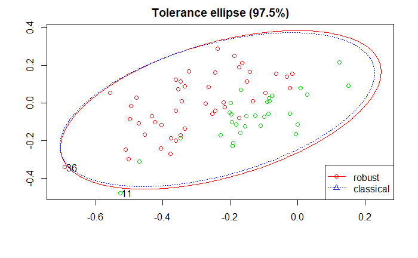

```r
col <- ifelse(hemophilia$gr == "carrier", 2, 3)
plot(mc.9, which="tolEllipsePlot", class=TRUE, col=col)
```

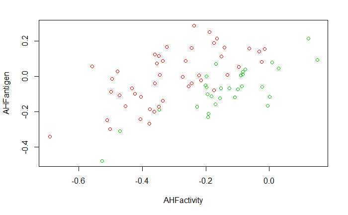

```r
plot(AHFantigen~AHFactivity, data=hemophilia, col=as.numeric(as.factor(gr))+1)
```

La gráfica anterior indica que es apropiado hacer un análisis discriminante lineal. En este diagrama, los puntos verdes representan a las sanas, mientras que los portadores de hemofilia se representan con puntos de color rojo.

```r
datos.9 <- melt(hemophilia, value.name = "valor")
aggregate(formula = valor ~ gr + variable, data = datos.9,  FUN = function(x){shapiro.test(x)$p.value})
```

| gr | variable | valor |
| --- | --- | --- |
| carrier | AHFactivity | 0.69844425 |
| normal | AHFactivity | 0.05190836 |
| carrier | AHFantigen | 0.61526438 |
| normal | AHFantigen | 0.36964763 |

Todos tienen p-value mayor a 0.05, entonces no se rechaza y decimos que son todos normales.

%%Análisis discriminante lineal

```r
modelo_lda.9 <- lda(formula = gr ~ AHFactivity + AHFantigen, data = hemophilia)
modelo_lda.9
```

```
Call:
lda(gr ~ AHFactivity + AHFantigen, data = hemophilia)

Prior probabilities of groups:
carrier  normal
    0.6     0.4

Group means:
        AHFactivity   AHFantigen
carrier  -0.3079467 -0.005991111
normal   -0.1348700 -0.077856667

Coefficients of linear discriminants:
                  LD1
AHFactivity  9.032787
AHFantigen  -8.006605
```

3. Usando la función anterior clasificar las nuevas observaciones

```r
nuevas_observaciones <- data.frame(AHFactivity = c(-.112,-.059,.064,-.043,-.05,-.094,-.123,-.011,-.21,-.126), AHFantigen = c(-.279,-.068,.012,-.052,-.098,-.113,-.143,-.037,-.09,-.019) )
```

```r
predict(object = modelo_lda.9, newdata = nuevas_observaciones)
```

```
$class
 [1] normal normal normal normal normal normal normal normal normal normal
Levels: carrier normal

$posterior
       carrier    normal
1  0.003116444 0.9968836
2  0.039977709 0.9600223
3  0.014994965 0.9850050
4  0.038651528 0.9613485
5  0.020507729 0.9794923
6  0.036507036 0.9634930
7  0.038179236 0.9618208
8  0.027249432 0.9727506
9  0.345653749 0.6543463
10 0.260152876 0.7398471

$x
         LD1
1  3.1003132
2  1.8896574
3  2.3601618
4  1.9060763
5  2.2111506
6  1.9338070
7  1.9120543
8  2.0750264
9  0.7018518
10 0.8921370
```

```r
predicciones <- predict(object = modelo_lda.9, newdata = hemophilia[, c(1,2)], method = "predictive")
table(hemophilia$gr, predicciones$class, dnn = c("Clase real", "Clase predicha"))
```

```
          Clase predicha
Clase real carrier normal
   carrier      38      7
   normal        4     26
```

```r
trainig_error <- mean(hemophilia$gr != predicciones$class) * 100
paste("trainig_error=", trainig_error, "%")
```

```
[1] "trainig_error= 14.6666666666667 %"
```